# RNAseq_Assign

# Annotated Differentially Expressed Gene Function

```r
get_downregulated <- function(df){
    key <- intersect(rownames(df)[which(df$log2FoldChange<=-1)], rownames(df)[which(df$pvalue<=0.05)])
    results <- as.data.frame((df)[which(rownames(df) %in% key),])
    return(results)
}

annotate_de_genes <- function(df){

    df$hgnc_symbol <- rownames(df)
    mart <- useMart(biomart = "ensembl", dataset = "hsapiens_gene_ensembl")
    info <- getBM(attributes=c("hgnc_symbol",
                               "ensembl_gene_id_version",
                               "chromosome_name",
                               "start_position",
                               "end_position",
                               "strand",
                               "entrezgene_description"),
                  filters = c("hgnc_symbol"),
                  values = df$hgnc_symbol,
                  mart = mart,
                  useCache=FALSE)

    tmp <- merge(df, info, by="hgnc_symbol")
    tmp$strand <- gsub("-1", "-", tmp$strand)
    tmp$strand <- gsub("1", "+", tmp$strand)
    tmp$hgnc_symbol <- make.names(tmp$hgnc_symbol, unique = T)
    tmp <- tmp[!grepl("CHR", tmp$chromosome_name),]

    output_col <- c("Gene", "Ensembl ID", "Chromosome", "Start", "Stop", "Strand", "Description", "Log2FC", "P-value", "Adj P-value")
    tmp <- subset(tmp, select=c(hgnc_symbol, ensembl_gene_id_version, chromosome_name, start_position, end_position, strand, entrezgene_description, log2FoldChange, pvalue, padj))
    colnames(tmp) <- output_col

    if(min(tmp$Log2FC) > 0){
        tmp <- tmp[order(-tmp$Log2FC),]
    }else{
        tmp <- tmp[order(tmp$Log2FC),]
    }

    return(tmp)

}
```

# Submit function and Annotate using biomaRt and write to a file. Created the .txt file, moved it to the data folder, and transferred the information when writing the table.

```r
de_up = get_upregulated(as.data.frame(res1))
de_down = get_downregulated(as.data.frame(res1))
upregulated_genes = annotate_de_genes(de_up)
downregulated_genes = annotate_de_genes(de_down)

head(upregulated_genes)
```

```
##        Gene         Ensembl ID Chromosome    Start     Stop Strand
## 21    ID3.1  ENSG00000117318.9          1 23557926 23559501      -
## 18      ID1  ENSG00000125968.9         20 31605283 31606515      +
## 2  ADAMTS12 ENSG00000151388.11          5 33523535 33892019      -
## 42 SERPINA3 ENSG00000196136.18         14 94612384 94624055      +
## 19      ID2 ENSG00000115738.10          2  8678845  8684461      +
## 7    COL9A3 ENSG00000092758.18         20 62816244 62841159      +
##                                                  Description   Log2FC
## 21                                inhibitor of DNA binding 3 5.332703
## 18                                inhibitor of DNA binding 1 4.640650
## 2  ADAM metallopeptidase with thrombospondin type 1 motif 12 3.894302
## 42                                  serpin family A member 3 2.509672
## 19                                inhibitor of DNA binding 2 2.375634
## 7                             collagen type IX alpha 3 chain 2.015109
##         P-value  Adj P-value
## 21 3.784877e-59 2.178470e-55
## 18 8.840703e-06 5.586695e-01
## 2  2.032739e-07 2.821097e-03
## 42 1.381098e-07 6.684160e-05
## 19 1.757574e-50 7.811847e-47
## 7  7.411175e-11 3.359695e-08
```

```r
head(downregulated_genes)
```

[output not shown]

```r
write.table(upregulated_genes, "/home/rstudio/rstudio/data/upregulated_genes.txt", sep="\t", quote = F)
write.table(downregulated_genes, "/home/rstudio/rstudio/data/downregulated_genes.txt", sep="\t", quote = F)
```

# Volcano Plot

# Useful to show how many genes are differentially expressed in the tumour vs control samples. The most upregulated genes are shown on the right and the downregulated genes are on the left. Anything below the threshold line is known to be insignificant in gene expression between the tumour and control samples. Blue and red are significant gene expressions, but red are outliers for tumour effecting genes and therefore highly differentially expressed. The -log10P represents the p-values and the level of significance of each gene. The log2 fold change represents the difference between the levels of expression for each gene between the tumour and control samples.

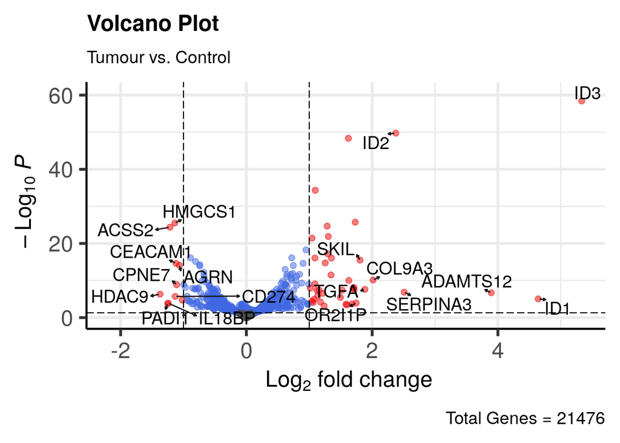

```r
## remove NA values from results
res1 = na.omit(res1)

## calculate min/max axis values for plot
min_width = min(res1$log2FoldChange)
max_width = max(res1$log2FoldChange)
max_height = -log10(min(res1[res1$pvalue>0, 5]))

## Grab top 10 up-reg genes for plot
up = subset(res1, res1$log2FoldChange > 1 & res1$pvalue <= 0.05)
up = up[order(-up$log2FoldChange),]
up_list = head(rownames(up), n=10L)

## Grab top 10 down-reg genes for plot
down = subset(res1, res1$log2FoldChange < -1 & res1$pvalue <= 0.05)
down = down[order(down$log2FoldChange),]
down_list = head(rownames(down), n=10L)

## place top 20 DE genes in vector (optinal...)
plot_top_20 = c(up_list, down_list)

EnhancedVolcano(res1,
                lab=rownames(res1),
                x="log2FoldChange",
                y="pvalue",
                selectLab=plot_top_20,
                drawConnectors=TRUE,
                legendPosition = "none",
                FCcutoff=1.0,
                pCutoff=0.05,
                title="Volcano Plot",
                subtitle="Tumour vs. Control",
                caption = paste0('Total Genes = ', nrow(res1)),
                xlim=c(min_width, max_width),
                ylim=c(0, max_height))
```